# sisg-aqg-2015-p4

SISG module 23

July 24, 2015

```r
# ===============================================================
# Summer Institute in Statistical Genetics, 2015, Seattle
# Advanced Quantitative Genetics
# Practical 3
# Date:
# Author:
# ===============================================================
```

[Link to GCTA]{cnsgenomics.com/software/gcta/} [Link to power calculator (in Shiny)]{cnsgenomics.com/shiny/gctaPower/}

```r
library(knitr)
# see https://github.com/yihui/knitr/issues/277
opts_knit$set(root.dir ='C:/Users/vonholle/Documents/grad_school/misc/training/sisg-2015/module23/sisg-2015-module23')
#setwd("C:/Users/vonholle/Documents/grad_school/misc/training/sisg-2015/module23/sisg-2015-module23") # Windows
```

```r
# Read in the gzipped GRM file
grm <- read.table("practical_4/data/QIMRX.grm.gz")
head(grm)
```

```
##   V1 V2     V3          V4
## 1  1  1 265805 0.982474100
## 2  2  1 265771 0.430762000
## 3  2  2 265791 0.997156000
## 4  3  1 261504 0.001788883
## 5  3  2 261492 0.001014441
## 6  3  3 261529 1.000038000
```

## Estimating proportion of phenotypic variation due to additive genetic factors using GCTA

### Let’s use the GRM matrix to estimate the proportion of phenotypic variance explained by additive genome-wide SNPs for height and serum transferrin.

```r
# Once you've set up your binary directory for this analysis and have set R to that directory (I moved the binaries to my working directory above), do this:
system("gcta --grm practical_4/data/QIMRX --pheno practical_4/data/HT_T_X.pheno --mpheno 1 --reml --out practical_4/results/QIMRX_1", intern=TRUE)

system("gcta --grm practical_4/data/QIMRX --pheno practical_4/data/HT_T_X.pheno --mpheno 2 --reml --out practical_4/results/QIMRX_2", intern=T)
```

```r
# Read in GREML result files
hsq.1 <- read.table("practical_4/results/QIMRX_1.hsq", header = T, fill = T)
hsq.2 <- read.table("practical_4/results/QIMRX_2.hsq", header = T, fill = T)
head(hsq.1)
```

```
##    Source     Variance       SE
## 1    V(G)     0.795498 0.051003
## 2    V(e)     0.238877 0.041478
## 3      Vp     1.034375 0.028005
## 4 V(G)/Vp     0.769062 0.040840
## 5    logL -1416.193000       NA
## 6   logL0 -1466.335000       NA
```

## Exercise 1

- What is the percentage of phenotypic variance that is explained by common SNPs for both traits?
- Are the heritability estimates significant?
- Are the heritability values what you expect?

We will now take a closer look at some of the properties of the GRM by reading using R

```r
names(grm) <- c("IND_1", "IND_2", "SNP_NUM", "REL")
dim(grm)
```

```
## [1] 11817091        4
```

```r
# Take out the diagonal elements
grm.diag <- grm[which(grm$IND_1 == grm$IND_2), ]
dim(grm.diag)
```

```
## [1] 4861    4
```

```r
head(grm.diag)
```

```
##    IND_1 IND_2 SNP_NUM       REL
## 1      1     1  265805 0.9824741
## 3      2     2  265791 0.9971560
## 6      3     3  261529 1.0000380
## 10     4     4  265743 1.0015680
## 15     5     5  265796 1.0079740
## 21     6     6  265615 1.0066630
```

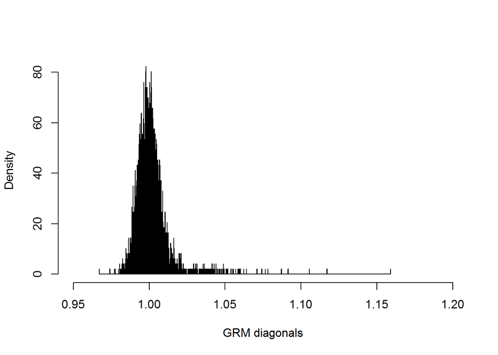

```r
# Take out the GRM off-diagonal elements
grm.off.diag <- grm[which(grm$IND_1 != grm$IND_2), ]
# Make a histogram of the diagonals
hist(grm.diag[, 4], breaks = 2500, freq = F,
xlab = "GRM diagonals", xlim = c(0.95, 1.2), main = "")
```

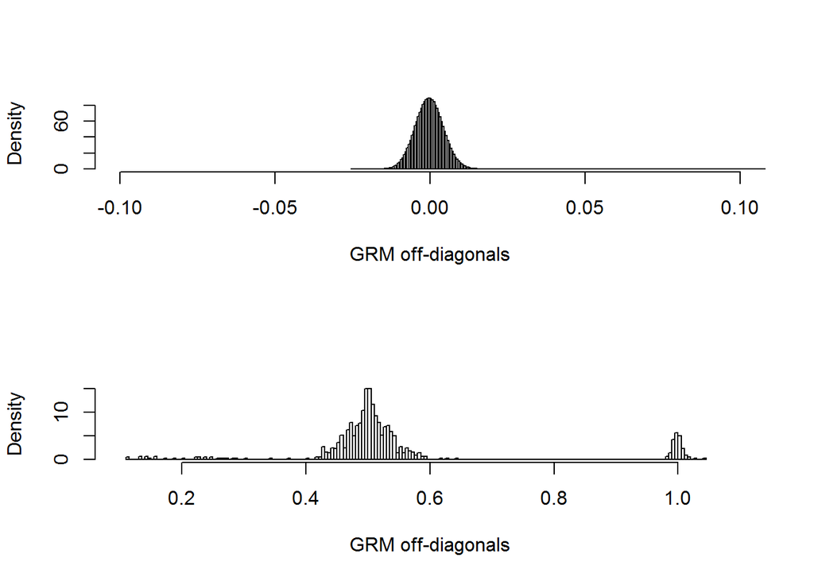

```r
# Make a histogram of the GRM off-diagonal relatedness estimates
par(mfrow = c(2, 1))
hist(grm.off.diag[, 4], breaks = 2500, freq = F,
xlab = "GRM off-diagonals", xlim = c(-0.1, 0.1), main = "")
hist(grm.off.diag[which(grm.off.diag[, 4] > 0.1), 4],
breaks = 200, freq = F,
xlab = "GRM off-diagonals", xlim = c(0.1, 1.1), main = "")
```

In the above results the relatedness may have affected the estimate of heritability (Fig. 2 panel 2). We will remove the relatedness and see whether the results change. This is done with GCTA via the –grm-cutoff 0.025 flag and the line in listing 11.

#### Note: run this following chunk once to get the files then set to eval=F

```r
system("gcta --mgrm practical_4/data/QIMRX_multi.txt --pheno practical_4/data/HT_T_X.pheno --mpheno 1 --reml --grm-cutoff 0.025 --out practical_4/results/QIMRX_nr_1", intern=T)

system("gcta --mgrm practical_4/data/QIMRX_multi.txt --pheno practical_4/data/HT_T_X.pheno --mpheno 2 --reml --grm-cutoff 0.025 --out practical_4/results/QIMRX_nr_2", intern=T)
```

## Exercise 2

- Repeat the REML analyses as in exercise 1 but with relatedness removed
- Compare the results with those in exercise 1 (using listing 9) and from Yang et al. (2010) (for trait 1 height)

```r
# Read in GREML result files without relatedness.
grm.nr <- read.table("practical_4/data/QIMRX_nr.grm.gz")
# Create the same figures as above
# Note that these are only example file extensions
# and may change depending on what you want to call the files
hsq.1.nr <- read.table("practical_4/results/QIMRX_nr_1.hsq", header = T, fill = T)
hsq.2.nr <- read.table("practical_4/results/QIMRX_nr_2.hsq", header = T, fill = T)
```

Notes from lecture today: $SE(\hat h^2_{SNP}) = frac{300}{N}$.

## Partitioning the variance via minor allele frequency

We will now investigate partitioning variance components by creating two GRM matrices. One will be created with SNPs with lower MAFs and another with those that have higher MAFs.

The GRMs were built with the command and it is best if you try to build these in your own time as the process is computationally expensive.

### Preparing the GRMs for variance partitioning

```r
system("gcta --bfile practical_4/data/QIMRX_cleaned --extract practical_4/data/bot_maf_snps.txt --autosome --make-grm --keep QIMRX_nr.grm.id --out practical_4/data/QIMRX_bot_maf_snps", intern = T)

system("gcta --bfile practical_4/data/QIMRX_cleaned --extract practical_4/data/top_maf_snps.txt --autosome --make-grm --keep QIMRX_nr.grm.id --out practical_4/data/QIMRX_top_maf_snps", intern = T)
```

### Partitioning variance components via GREML

#### Note: only run this once to get output file then set to eval=F. takes too long.

```r
system("gcta --mgrm practical_4/data/QIMRX_multi.txt --pheno practical_4/data/HT_T_X.pheno --mpheno 1 --reml --out practical_4/results/QIMRX_1_multi_nr", intern=T)
```

```r
hsq.1.multi.nr <- read.table("practical_4/results/QIMRX_1_multi_nr.hsq", header = T, fill = T)
head(hsq.1.multi.nr)
```

```
##     Source Variance       SE
## 1    V(G1) 0.180170 0.125732
## 2    V(G2) 0.195985 0.150661
## 3     V(e) 0.651210 0.148995
## 4       Vp 1.027365 0.030382
## 5 V(G1)/Vp 0.175371 0.122067
## 6 V(G2)/Vp 0.190765 0.146306
```

## Exercise 3

- Repeat for phenotype 2

### Partitioning variance components via GREML

#### Note: only run this once to get output file then set to eval=F. takes too long.

```r
system("gcta --mgrm practical_4/data/QIMRX_multi.txt --pheno practical_4/data/HT_T_X.pheno --mpheno 2 --reml --out practical_4/results/QIMRX_2_multi_nr", intern=T)
```

```r
hsq.2.multi.nr <- read.table("practical_4/results/QIMRX_2_multi_nr.hsq", header = T, fill = T)
head(hsq.2.multi.nr)
```

```
##     Source Variance       SE
## 1    V(G1) 0.169624 0.138238
## 2    V(G2) 0.332319 0.160182
## 3     V(e) 0.426793 0.153726
## 4       Vp 0.928736 0.030388
## 5 V(G1)/Vp 0.182640 0.148504
## 6 V(G2)/Vp 0.357818 0.171376
```

- What do you observe for the different variance component estimates from the GRMs of low and high MAF SNPs?
- Is this what we expect?